## Improved grassland classification

The results below detail how remotely sensed satellite data was processed using a Support Vector Machine to generate a classification for improved grassland across the various islands of Shetland.

### Shetland Sentinel 2 satelitte dataset

A Sentinel 2 satellite spatial dataset was clipped using the Integrated Administration And Control System (IACS) field boundary shapefile for Shetland. This gave a spatial dataset comprising of land-based habitat only, excluding built areas and roads, as shown in Figure @ref(fig:plotSentRGB)

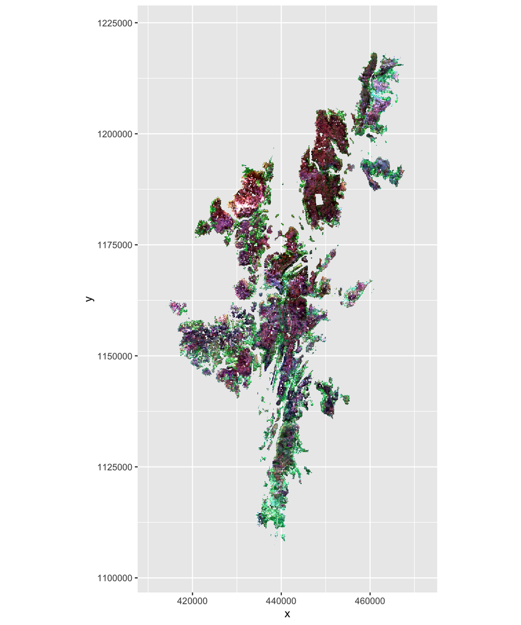

Clipped Sentinel 2 RGB composite of Shetland

### Sentinel 2 spectral bands used in habitat classification

The Sentinel dataset is represented as a layered set of images (a raster) known as a `RasterBrick` [@raster]. Each raster layer is a spatial representation of one of 11 different spectral sensor readings. The sensors used within the Shetland sentinel dataset are shown in Table @ref(tab:satBands).

| Band ID | Name | Wavelength (micrometer) |
| --- | --- | --- |
| 1 | Aerosol | 0.443 |
| 2 | Blue | 0.490 |
| 3 | Green | 0.560 |
| 4 | Red | 0.655 |
| 5 | Veg Red 1 | 0.705 |
| 6 | Veg Red 2 | 0.865 |
| 7 | Veg Red 3 | 0.740 |
| 8 | NIR | 0.783 |
| 8A | Veg Red 4 | 0.842 |
| 11 | SWIR 1 | 1.610 |
| 12 | SWIR 2 | 2.190 |

### Habitiat classification training data

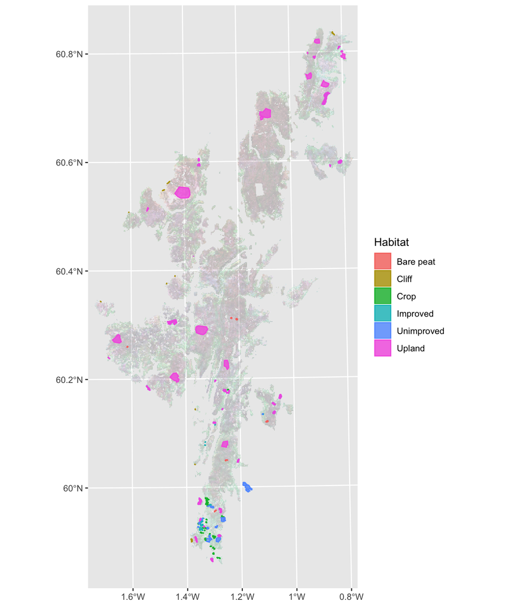

Habitat classification training areas

### Sampling of habitat training classes

Each habitat training dataset was randomly sampled in order to train a support vector machine classifier. Distributions for the sampled data for each training set are shown in Figure @ref(fig:plotSampleDistributions). The NIR and red vegetation spectra appear to be the most distinct across different habitat types.

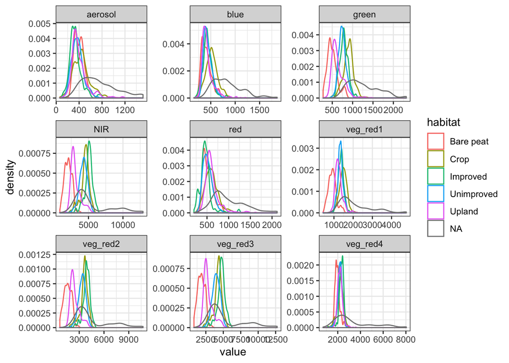

Sampled distributions for each training class, from the Sentinel 2 dataset of the Shetland landmass

### Search grid parameterisation

The SVM parameters used to create a number of different models are shown in Table @ref(tab:searchGrid).

| RBF sigma | Cost |
| --- | --- |
| 0.11 | 18 |
| 0.12 | 18 |
| 0.13 | 18 |
| 0.11 | 19 |
| 0.12 | 19 |
| 0.13 | 19 |
| 0.11 | 20 |
| 0.12 | 20 |
| 0.13 | 20 |

| Cost | RBF sigma | Accuracy | se |
| --- | --- | --- | --- |
| 20 | 0.13 | 0.8233010 | 0.0094407 |
| 19 | 0.13 | 0.8208738 | 0.0093362 |
| 18 | 0.13 | 0.8194175 | 0.0093179 |
| 19 | 0.12 | 0.8194175 | 0.0091478 |
| 20 | 0.12 | 0.8194175 | 0.0090903 |

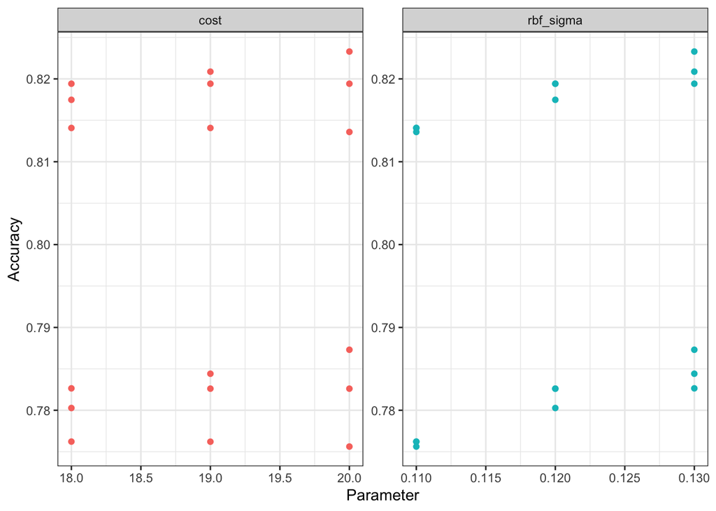